# Skalendokumentation ‘Falllbasiertes Lernen in der ersten Phase der Lehrerbildung’

## knowledge of classroom management

- source: own creation
- question type: open question
- number of items: 2
- names and label of items:
  - T1_wiss_crm_preav = “Nennen Sie präventive Maßnahmen, die für einen störungsfreien Unterricht sorgen sollen.”
  - T1_wiss_crm_bez = “Nennen Sie Maßnahmen, die die Lehrer-Schüler-Beziehung verbessern und so zu einem besseren Lernklima führen (Beziehungsförderung).”

## goal orientation

- source: adaption of PISA 2000, Feldtest
- question type: likert scale
- number of items: 9
- names and label of items:
  - T1_ziel_9 = “Inwiefern stimmen Sie folgenden Aussagen zu? Ich fühle mich am erfolgreichsten, … **wenn ich zeigen kann, dass ich schlau bin.**”
  - T1_ziel_7 = “Inwiefern stimmen Sie folgenden Aussagen zu? Ich fühle mich am erfolgreichsten, … **wenn ich als einziger die richtige Antwort weiß.**”
  - T1_ziel_4 = “Inwiefern stimmen Sie folgenden Aussagen zu? Ich fühle mich am erfolgreichsten, … **wenn ich einen neuen Weg herausfinde, ein Problem zu lösen.**”
  - T1_ziel_2 = “Inwiefern stimmen Sie folgenden Aussagen zu? Ich fühle mich am erfolgreichsten, … **wenn das Gelernte mich dazu bringt mehr erfahren zu wollen.**”
  - T1_ziel_1 = “Inwiefern stimmen Sie folgenden Aussagen zu? Ich fühle mich am erfolgreichsten, … **wenn ich ein kompliziertes Problem endlich bewältigt habe.**”
  - T1_ziel_8 = “Inwiefern stimmen Sie folgenden Aussagen zu? Ich fühle mich am erfolgreichsten, … **wenn ich bessere Noten bekomme als die anderen.**”
  - T1_ziel_6 = “Inwiefern stimmen Sie folgenden Aussagen zu? Ich fühle mich am erfolgreichsten, … **wenn ich mehr weiß als die anderen.**”
  - T1_ziel_3 = “Inwiefern stimmen Sie folgenden Aussagen zu? Ich fühle mich am erfolgreichsten, … **wenn das Seminar mich zum Nachdenken bringt.**”
  - T1_ziel_5 = “Inwiefern stimmen Sie folgenden Aussagen zu? Ich fühle mich am erfolgreichsten, … **wenn das Gelernte wirklich Sinn für mich macht.**”
- value lables and numbers:
  - 1 = “trifft überhaupt nicht zu”
  - 2 = “”
  - 3 = “”
  - 4 = “”
  - 5 = “”
  - 6 = “”
  - 7 = “trifft voll und ganz zu”
- inverted items: -
- subscales:
  - Aufgabenorieniterung: T1_ziel_1, T1_ziel_2, T1_ziel_3, T1_ziel_4, T1_ziel_5
  - Ich-orientierung: T1_ziel_6, T1_ziel_7, T1_ziel_8, T1_ziel_9
- item statistics

| item | n | mean | sd | min | max |
| --- | --- | --- | --- | --- | --- |
| T1_ziel_1 | 614 | 6.22 | 0.93 | 1 | 7 |
| T1_ziel_2 | 613 | 5.65 | 1.15 | 1 | 7 |
| T1_ziel_3 | 617 | 4.82 | 1.47 | 1 | 7 |
| T1_ziel_4 | 616 | 5.77 | 1.07 | 2 | 7 |
| T1_ziel_5 | 618 | 6.12 | 1.1 | 1 | 7 |
| T1_ziel_6 | 616 | 4.57 | 1.63 | 1 | 7 |
| T1_ziel_7 | 614 | 4.46 | 1.64 | 1 | 7 |
| T1_ziel_8 | 616 | 4.44 | 1.65 | 1 | 7 |
| T1_ziel_9 | 615 | 4.62 | 1.53 | 1 | 7 |

- subscale statistics

| subscale | n | mean | sd | min | max | McDonaldsOmega |
| --- | --- | --- | --- | --- | --- | --- |
| aufgebenorientierung | 618 | 5.72 | 0.8 | 2.6 | 7 | 0.81 |
| ichroientierung | 617 | 4.52 | 1.37 | 1 | 7 | 0.91 |

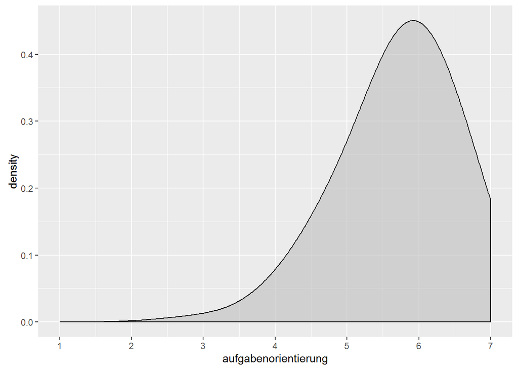

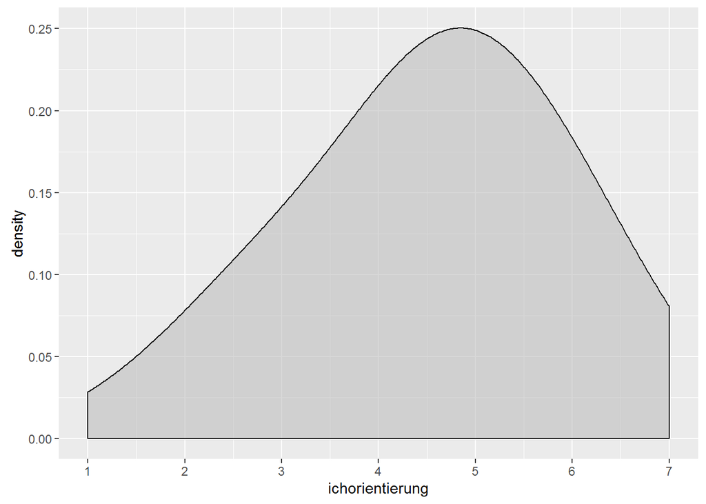

## need for cognition

- source: adaption of Bless et al.
- question type: likert scale
- number of items: 10
- names and label of items:
  - nfc_1 = “Die Aufgabe, neue Lösungen für Probleme zu finden, macht mir wirklich Spaß.”
  - nfc_2 = “Die Vorstellung, mich auf mein Denkvermögen zu verlassen, um es zu etwas zu bringen, spricht mich an.”
  - nfc_3 = “Ich würde lieber etwas tun, das wenig Denken erfordert, als etwas, das mit Sicherheit meine Denkfähigkeit herausfordert.”
  - nfc_4 = “Ich finde wenig Befriedigung darin, angestrengt und stundenlang nachzudenken.”
  - nfc_5 = “In erster Linie denke ich, weil ich muss.”
  - nfc_6 = “Denken entspricht nicht dem, was ich unter Spaß verstehe.”
  - nfc_7 = “Ich versuche, Situationen vorauszuahnen und zu vermeiden, in denen die Wahrscheinlichkeit groß ist, dass ich intensiv über etwas nachdenken muss.”
  - nfc_8 = “Ich habe es gern, wenn mein Leben voller kniffliger Aufgaben ist, die ich lösen muss.”
  - nfc_9 = “Ich würde komplizierte Probleme einfachen Problemen vorziehen.”
  - nfc_10 = “Es genügt mir, einfach die Antwort zu kennen, ohne die Gründe für die Antwort eines Problems zu verstehen.”
- value lables and numbers:
  - 1 = “trifft nicht zu”
  - 2 = “”
  - 3 = “”
  - 4 = “”
  - 5 = “”
  - 6 = “”
  - 7 = “trifft voll und ganz zu”
- inverted items: nfc_3, nfc_4, nfc_5, nfc_6, nfc_7, nfc_10
- subscales: -
- item statistics

| item | n | mean | sd | min | max |
| --- | --- | --- | --- | --- | --- |
| nfc_1 | 618 | 5.02 | 1.26 | 1 | 7 |
| nfc_2 | 615 | 5.2 | 1.22 | 1 | 7 |
| nfc_3 recoded | 614 | 5.15 | 1.45 | 1 | 7 |
| nfc_4 recoded | 616 | 4.53 | 1.58 | 1 | 7 |
| nfc_5 recoded | 616 | 5.46 | 1.52 | 1 | 7 |
| nfc_6 recoded | 616 | 5.15 | 1.46 | 1 | 7 |
| nfc_7 recoded | 618 | 5.2 | 1.59 | 1 | 7 |
| nfc_8 | 618 | 3.76 | 1.49 | 1 | 7 |
| nfc_9 | 619 | 3.33 | 1.49 | 1 | 7 |
| nfc_10 recoded | 618 | 5.6 | 1.38 | 1 | 7 |

- scale statistics

| n | mean | sd | min | max | McDonaldsOmega |
| --- | --- | --- | --- | --- | --- |
| 619 | 4.84 | 0.84 | 1.9 | 7 | 0.84 |

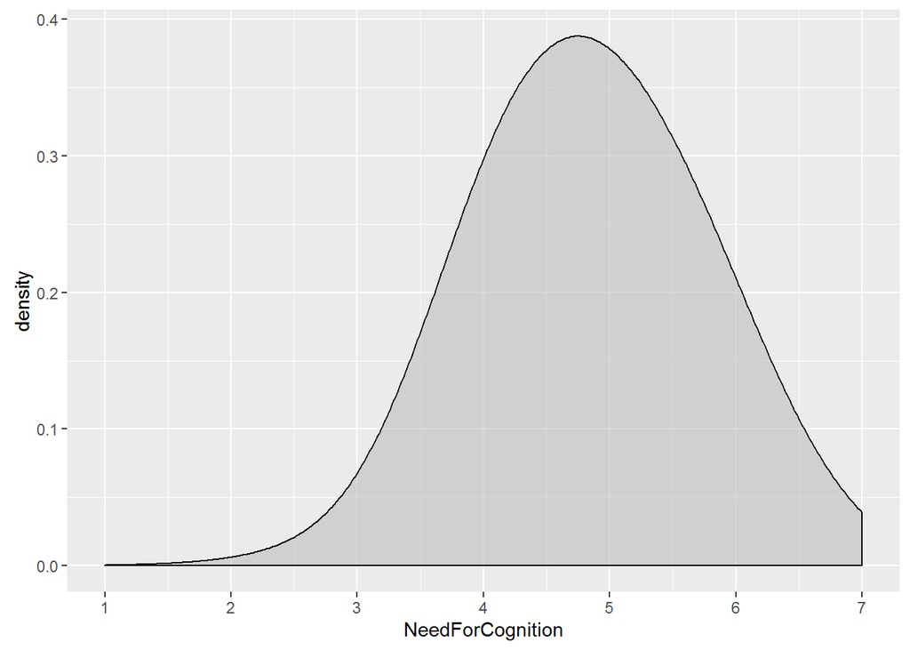

# Posttest

## submit date

T2_submitdate: Date and time when online questionnaire was submitted.

## start date

T2_startdate: Date and time when online questionnaire was started.

## Identification code

- source: own creation
- question type: open answer
- number of items: 1
- names and label of items:
  - code_2

## preparatory literature read

Indicates how much of the preparatory literture the participant read (four theoretical texts).

- source: own creation
- question type: multiple choice
- number of items: 4
- names and label of items:
  - T2_text_1 = “Ich habe folgende Theorietexte bereits gelesen: **Mayr, J. (2009): Klassen stimmig führen. In: Pädagogik, 61 (2), S. 34-37.**”
  - T2_text_2 = “Ich habe folgende Theorietexte bereits gelesen: **CRM- Techniken Evertson et al in Wellenreuther 278-284.pdf**”
  - T2_text_3 = “Ich habe folgende Theorietexte bereits gelesen: **CRM-Techniken Kounin in Wellenreuther 268-274.pdf**”
  - T2_text_4 = “Ich habe folgende Theorietexte bereits gelesen: **Handlungsstrategien CRM 4 Bereiche**”
- value lables and numbers:
  - 0 = not selected
  - 1 = selected
- item statistics

| text | frequency |
| --- | --- |
| T2_text_1 | 282 |
| T2_text_2 | 228 |
| T2_text_3 | 213 |
| T2_text_4 | 154 |

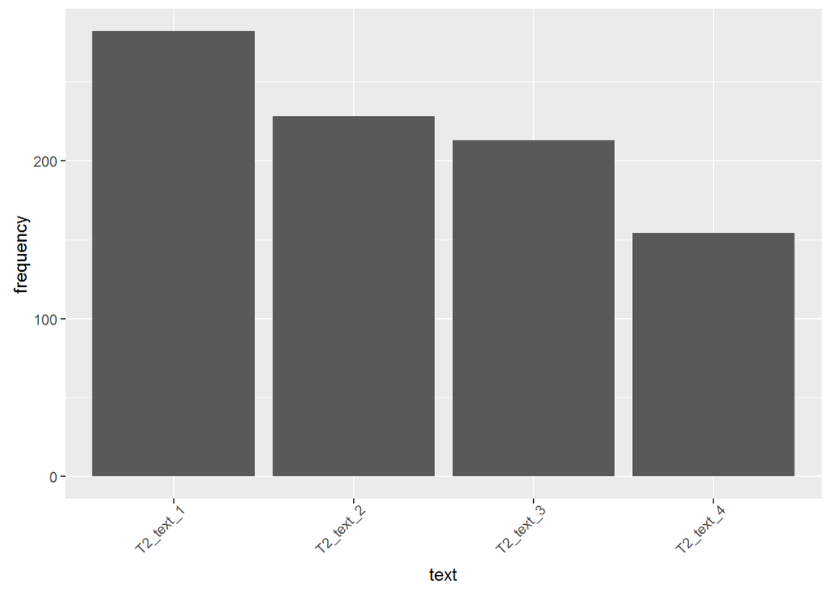

- scale statistics (sum of items used)

| n | mean | sd | min | max |
| --- | --- | --- | --- | --- |
| 575 | 1.53 | 1.54 | 0 | 4 |

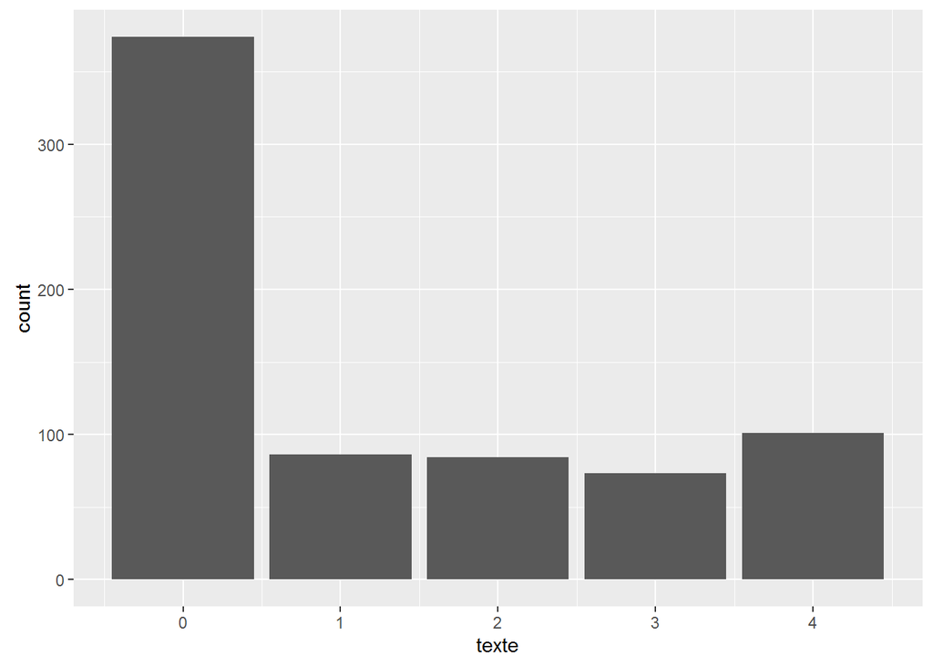

## attendance

Indicates how many of the two treatment sessions werde attended by the participant.

- source: own creation
- question type: multiple choice
- number of items: 2
- names and label of items:
  - anwesend_erst = “An welchen der Sitzungen zu Classroom Management haben Sie teilgenommen? **erste Sitzung**”
  - anwesend_zweit = “An welchen der Sitzungen zu Classroom Management haben Sie teilgenommen? **zweite Sitzung**”
- value lables and numbers:
  - 0 = not selected (please be aware that “not selected” could be either a decision by the participant or indicating s/he did not fill out this part of the questionnaire)
  - 1 = selected
- item statistics

| text | frequency |
| --- | --- |
| anwesend_erst | 515 |
| anwesend_zweit | 493 |

- scale statistics (sum of items used)

| n | mean | sd | min | max |
| --- | --- | --- | --- | --- |
| 575 | 1.75 | 0.47 | 0 | 2 |

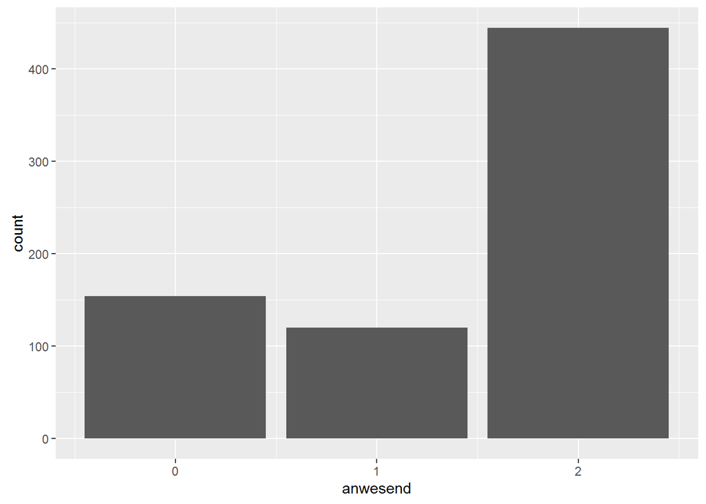

## value of classroom analysis

Indicates how much the participant values classroom analysis.

- source: own creation
- question type: likert scale
- number of items: 1
- names and label of items:
  - T2_nutz_T2 = “Wie hoch schätzen Sie den Nutzen der Analyse von Unterrichtsfällen ein?”
- value lables and numbers:
  - 1 = “sehr gering”
  - 2 = “”
  - 3 = “”
  - 4 = “sehr hoch”
- item statistics

| n | mean | sd | min | max |
| --- | --- | --- | --- | --- |
| 566 | 3.02 | 0.7 | 1 | 4 |

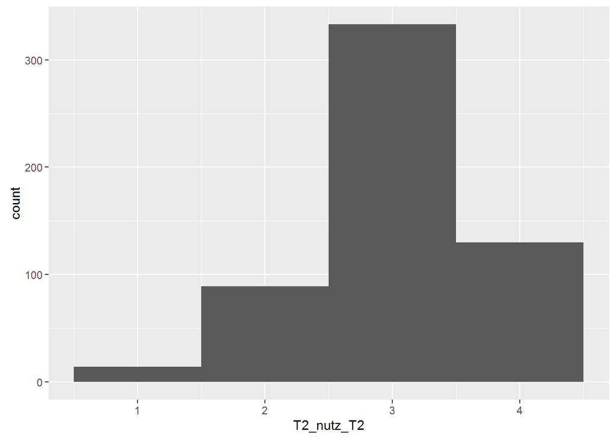

## perceived knowledge of classroom management

Indicates how high the participant estimates his/her own knowledge of classroom management.

- source: own creation
- question type: likert scale
- number of items: 1
- names and label of items:
  - T2_vorw_T2 = “Wie schätzen Sie Ihr eigenes Wissen zum Thema”Classroom Management" ein?"
- value lables and numbers:
  - 1 = “sehr gering”
  - 2 = “”
  - 3 = “”
  - 4 = “”
  - 5 = “”
  - 6 = “sehr hoch”
- item statistics

| n | mean | sd | min | max |
| --- | --- | --- | --- | --- |
| 567 | 3.68 | 0.87 | 1 | 6 |

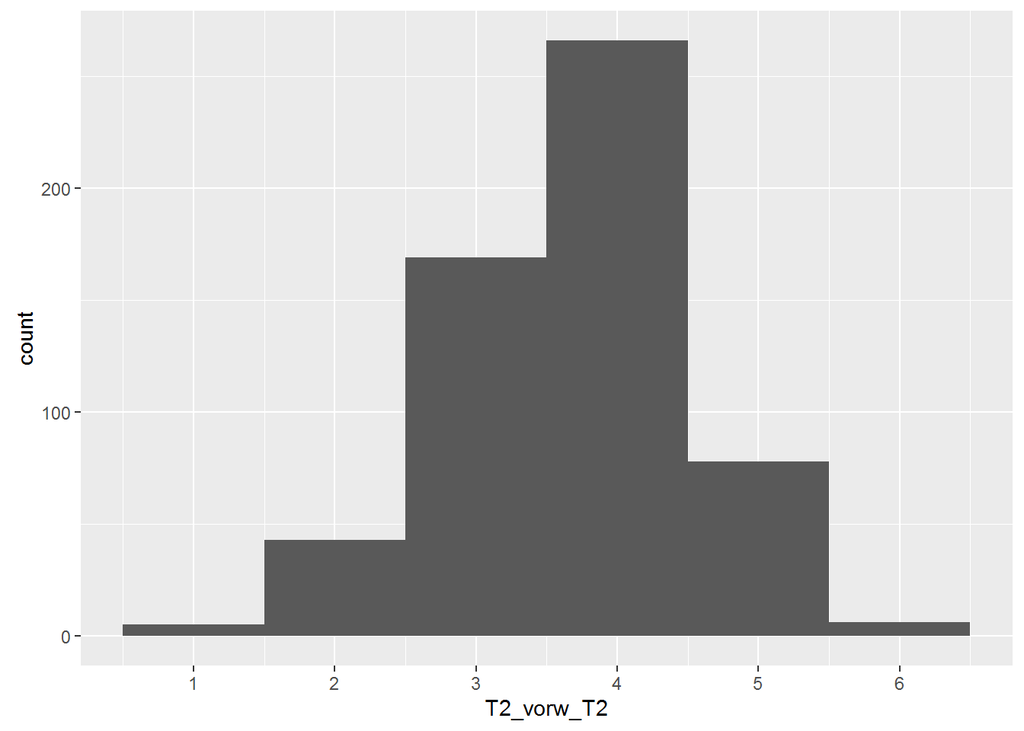

## acceptance of case-based learning

- source: adaption of Kleinknecht 2012
- question type: likert scale
- number of items: 7
- names and label of items:
  - akzrp_1 = “Die im Seminar und hier verwendeten Unterrichtsfälle… **können mir helfen, Details im Unterrichtsgeschehen wahrzunehmen**”
  - akzrp_2 = “Die im Seminar und hier verwendeten Unterrichtsfälle… **sind eine Anregung, um zukünftig über meinen eigenen Unterricht nachzudenken.**”
  - akzrp_3 = “Die im Seminar und hier verwendeten Unterrichtsfälle… **bieten mir ein geeignetes Aufwand-Nutzen-Verhältnis.**”
  - akzrp_4 = “Die im Seminar und hier verwendeten Unterrichtsfälle… **sind ein geeignetes Mittel, um Unterricht zu analysieren.**”
  - akzrp_5 = “Die im Seminar und hier verwendeten Unterrichtsfälle… **sind eine geeignete Grundlage, um über Unterricht zu diskutieren.**”
  - akzrp_6 = “Die im Seminar und hier verwendeten Unterrichtsfälle… **haben meine Aufmerksamkeit für ein besseres Classroom-Management erhöht.**”
  - akzrp_7 = “Die im Seminar und hier verwendeten Unterrichtsfälle… **haben mir wichtige Ideen für den Austausch mit anderen Lehramtsstudierenden gegeben.**”
- value lables and numbers:
  - 1 = “trifft nicht zu”
  - 2 = “trifft eher nicht zu”
  - 3 = “trifft eher zu”
  - 4 = “trifft zu”
- inverted items: -
- subscales: -
- item statistics

| item | n | mean | sd | min | max |
| --- | --- | --- | --- | --- | --- |
| akzrp_1 | 568 | 3.11 | 0.64 | 1 | 4 |
| akzrp_2 | 566 | 3.32 | 0.7 | 1 | 4 |
| akzrp_3 | 567 | 2.64 | 0.71 | 1 | 4 |
| akzrp_4 | 567 | 3.14 | 0.74 | 1 | 4 |
| akzrp_5 | 563 | 3.29 | 0.67 | 1 | 4 |
| akzrp_6 | 565 | 3.13 | 0.81 | 1 | 4 |
| akzrp_7 | 566 | 2.64 | 0.87 | 1 | 4 |

- scale statistics

| n | mean | sd | min | max | McDonaldsOmega |
| --- | --- | --- | --- | --- | --- |
| 568 | 3.04 | 0.53 | 1 | 4 | 0.9 |

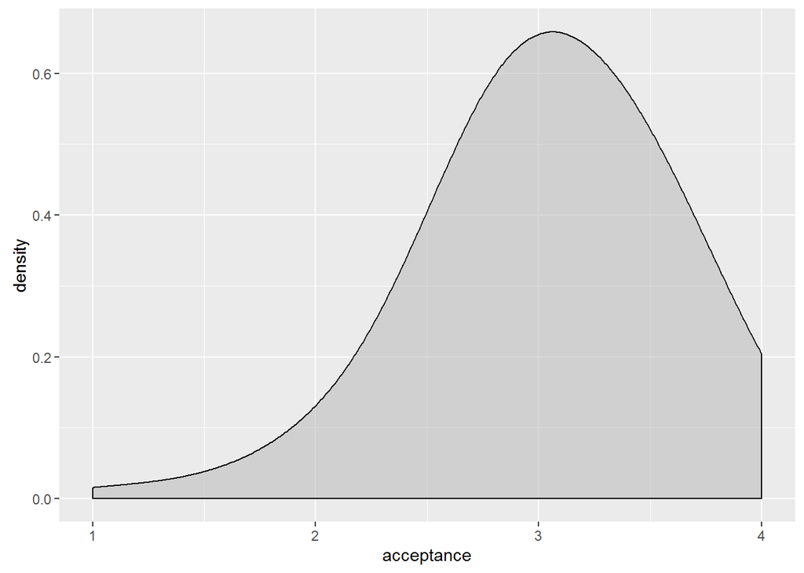

## benefit of case-based learning

- source: adaption of Kleinknecht 2012
- question type: likert scale
- number of items: 6
- names and label of items:
  - ertr_1 = “Bitte geben Sie an, inwieweit die folgenden Aussagen zutreffen. **Das Arbeiten mit Unterrichtsfällen sollte fester Bestandteil der Ausbildung von LehrerInnen sein.**”
  - ertr_2 = “Bitte geben Sie an, inwieweit die folgenden Aussagen zutreffen. **Durch das Arbeiten mit Unterrichtsfällen wird die Unterrichtspraxis verändert.**”
  - ertr_3 = “Bitte geben Sie an, inwieweit die folgenden Aussagen zutreffen. **Wissen, das ich mir hier aneigne, kann ich in der Praxis anwenden.**”
  - ertr_4 = “Bitte geben Sie an, inwieweit die folgenden Aussagen zutreffen. **Ich halte es für sinnvoll, in Zukunft mit Fällen fremden Unterrichts zu arbeiten.**”
  - ertr_5 = “Bitte geben Sie an, inwieweit die folgenden Aussagen zutreffen. **Ich halte es für sinnvoll, in Zukunft mit Fällen eigenen Unterrichts zu arbeiten.**”
  - ertr_6 = “Bitte geben Sie an, inwieweit die folgenden Aussagen zutreffen. **Ich habe Lust, weiterhin mit Unterrichtsfällen zu arbeiten.**”
- value lables and numbers:
  - 1 = “trifft nicht zu”
  - 2 = “trifft eher nicht zu”
  - 3 = “trifft eher zu”
  - 4 = “trifft zu”
- inverted items: -
- subscales: -
- item statistics

| item | n | mean | sd | min | max |
| --- | --- | --- | --- | --- | --- |
| ertr_1 | 569 | 3.31 | 0.74 | 1 | 4 |
| ertr_2 | 567 | 2.79 | 0.76 | 1 | 4 |
| ertr_3 | 568 | 3.01 | 0.77 | 1 | 4 |
| ertr_4 | 565 | 3.05 | 0.75 | 1 | 4 |
| ertr_5 | 566 | 3.31 | 0.72 | 1 | 4 |
| ertr_6 | 569 | 2.99 | 0.81 | 1 | 4 |

- scale statistics

| n | mean | sd | min | max | McDonaldsOmega |
| --- | --- | --- | --- | --- | --- |
| 569 | 3.08 | 0.59 | 1 | 4 | 0.9 |

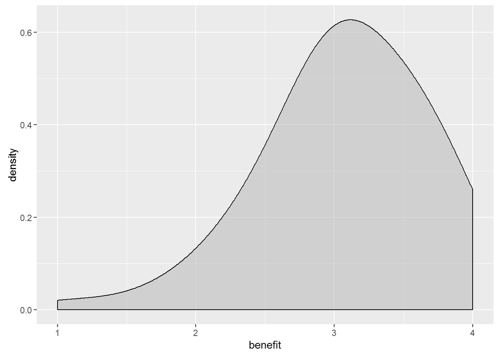

## analysis of classroom sequence

Students were asked to write analyses on three classroom sequences (1 text, 2 videos) on the topic of classroom management, using text boxes.

Screenshots of one sequence, using text:

[figure not shown]

and one using video:

[figure not shown]

The text that appeared after clicking on “Analyseschritten (hier klicken)”:

> - Was ist die Ausgangssituation?
> - Wie handelt die Lehrperson und welche weiteren Optionen gibt es?
> - Welche Ursachen/ Konsequenzen haben diese Optionen?
> - Für welche Option würden Sie sich entscheiden? Warum?
- source: own creation
- question type: open question
- number of items: 3 (1 text, 2 video sequences)
- names and label of items:
  - offen43_3: “Bitte analysieren Sie die Sequenz bezüglich der Unterrichtsgestaltung, Verhaltenskontrolle und Beziehungsgestaltung mit folgenden Analyseschritten (hier klicken)” + **Text** Sequence
  - offen43_4: “Bitte analysieren Sie die Sequenz bezüglich der Unterrichtsgestaltung, Verhaltenskontrolle und Beziehungsgestaltung mit folgenden Analyseschritten (hier klicken)” + **Video** Sequence
  - offen43_5: “Bitte analysieren Sie die Sequenz bezüglich der Unterrichtsgestaltung, Verhaltenskontrolle und Beziehungsgestaltung mit folgenden Analyseschritten (hier klicken) + **Video** Sequence”

## Emotions towards case-based learning

- source: adaption of Pekrun 1992, AEQ
- question type: likert scale
- number of items: 8
- names and label of items:
  - T2_emo_1 = “Bitte geben Sie an, wie sie sich in Lernsituationen mit Fällen ganz allgemein fühlen. **Ich eigne mir gern neues Wissen mittels Fällen an.**”
  - T2_emo_2 = “Bitte geben Sie an, wie sie sich in Lernsituationen mit Fällen ganz allgemein fühlen. **Ich blicke optimistisch auf das Lernen mit Fällen.**”
  - T2_emo_3 = “Bitte geben Sie an, wie sie sich in Lernsituationen mit Fällen ganz allgemein fühlen. **Ich bin stolz auf meine Fähigkeiten.**”
  - T2_emo_4 = “Bitte geben Sie an, wie sie sich in Lernsituationen mit Fällen ganz allgemein fühlen. **Lernen mit Fällen macht mich gereizt.**”
  - T2_emo_5 = “Bitte geben Sie an, wie sie sich in Lernsituationen mit Fällen ganz allgemein fühlen. **Ich werde angespannt und nervös beim Lernen mit Fällen.**”
  - T2_emo_6 = “Bitte geben Sie an, wie sie sich in Lernsituationen mit Fällen ganz allgemein fühlen. **Ich schäme mich, dass ich die einfachsten Sachen manchmal nicht behalten kann.**”
  - T2_emo_7 = “Bitte geben Sie an, wie sie sich in Lernsituationen mit Fällen ganz allgemein fühlen. **Ich fühle mich hilflos, wenn ich an das Lernen mit Fällen denke.**”
  - T2_emo_8 = “Bitte geben Sie an, wie sie sich in Lernsituationen mit Fällen ganz allgemein fühlen. **Lernen mit Fällen langweilt mich zu Tode.**”
- value lables and numbers:
  - 1 = “überhaupt nicht”
  - 2 = “ein wenig”
  - 3 = “ziemlich”
  - 4 = “sehr”
- inverted items: -
- subscales
  - enjoyment (Freude): T2_emo_1, T2_emo_2, T2_emo_3
  - anger (Ärger): T2_emo_4
  - anxiety (Angst): T2_emo_5, T2_emo_7
  - boredom (Langeweile): T2_emo_8
  - shame (Scham): T2_emo_6
- item statistics

| item | n | mean | sd | min | max |
| --- | --- | --- | --- | --- | --- |
| T2_emo_1 | 551 | 2.8 | 0.75 | 1 | 4 |
| T2_emo_2 | 549 | 2.82 | 0.75 | 1 | 4 |
| T2_emo_3 | 548 | 2.46 | 0.81 | 1 | 4 |
| T2_emo_4 | 548 | 1.58 | 0.76 | 1 | 4 |
| T2_emo_5 | 548 | 1.23 | 0.49 | 1 | 4 |
| T2_emo_6 | 550 | 1.26 | 0.55 | 1 | 4 |
| T2_emo_7 | 548 | 1.16 | 0.42 | 1 | 4 |
| T2_emo_8 | 551 | 1.57 | 0.74 | 1 | 4 |

- subscale statistics

| subscale | n | mean | sd | min | max |
| --- | --- | --- | --- | --- | --- |
| enjoyment | 542 | 2.7 | 0.6 | 1 | 4 |
| anxiety | 545 | 1.19 | 0.39 | 1 | 3.5 |

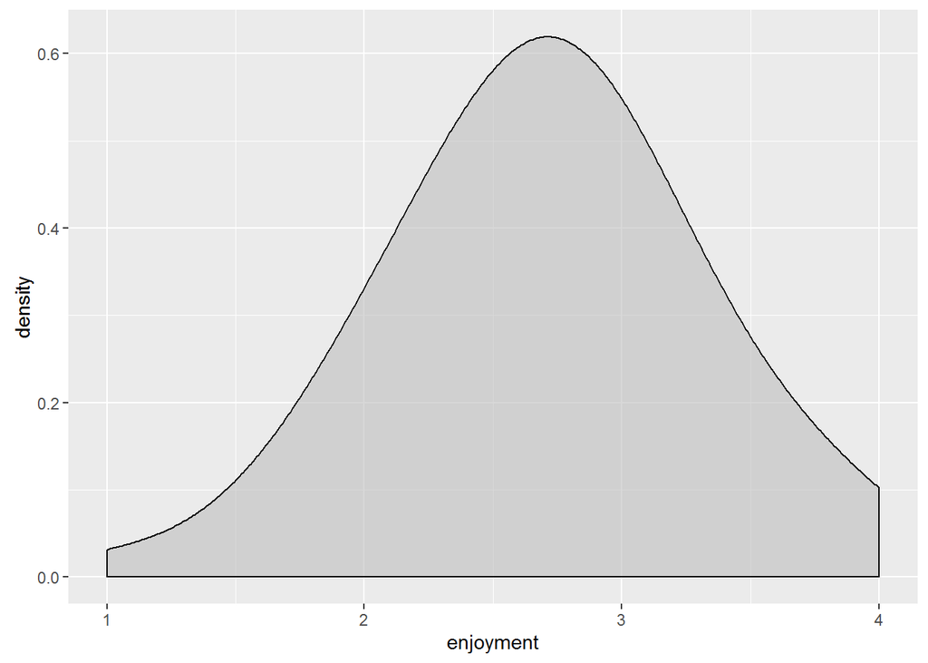

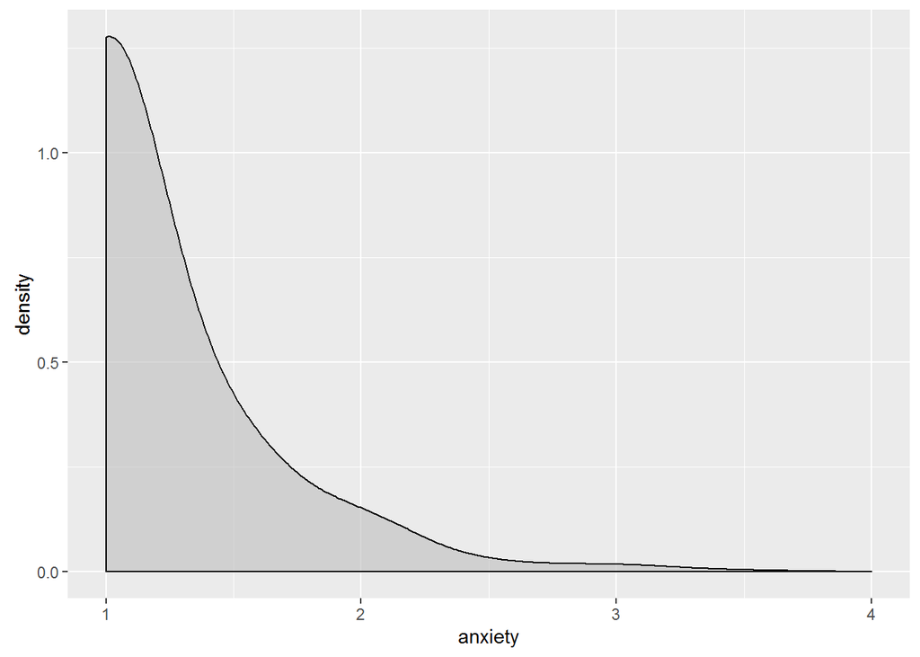

## perceived gains in knowledge

- source: own creation
- question type: likert scale
- number of items: 2
- names and label of items:
  - lernzuw_KompA = “Ich kann Unterricht nun besser analysieren als bei der ersten Bearbeitung dieser Online-Umgebung vor 3 Wochen.”
  - lernzuw_Crm = “Ich habe eine genaue Vorstellung davon, was Classroom Management ist.”
- value lables and numbers:
  - 1 = “stimme überhaupt nicht zu”
  - 2 = “”
  - 3 = “”
  - 4 = “”
  - 5 = “stimme voll und ganz zu”
- inverted items: -
- subscales: -
- item statistics

| item | n | mean | sd | min | max |
| --- | --- | --- | --- | --- | --- |
| lernzuw_KompA | 550 | 3.51 | 1.03 | 1 | 5 |
| lernzuw_Crm | 547 | 3.57 | 0.87 | 1 | 5 |

## willingness to reflect (acting)

| item | n | mean | sd | min | max |
| --- | --- | --- | --- | --- | --- |
| T2_RefBer1_1 | 551 | 3.64 | 0.93 | 1 | 5 |
| T2_RefBer1_2 | 551 | 3.28 | 0.99 | 1 | 5 |
| T2_RefBer1_3 | 548 | 3.4 | 0.99 | 1 | 5 |
| T2_RefBer1_4 | 549 | 3.46 | 1.05 | 1 | 5 |

- scale statistics

| n | mean | sd | min | max | McDonaldsOmega |
| --- | --- | --- | --- | --- | --- |
| 552 | 3.44 | 0.77 | 1 | 5 | 0.86 |

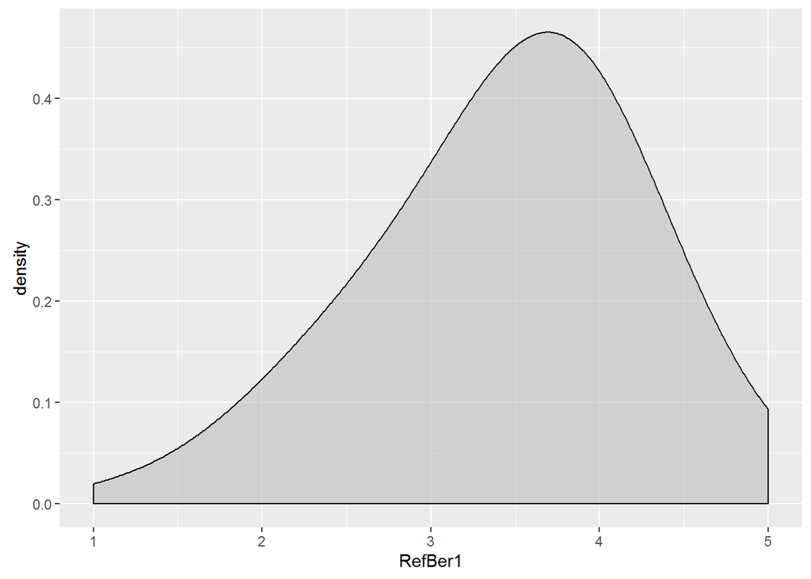

## willingness to reflect (attitude)

- source: adaption of Hosenfeld, A. (2010). *Führt Unterrichtsrückmeldung zu Unterrichtsentwicklung?* Die Wirkung von videographischer und schriftlicher Rückmeldung bei Lehrkräften der vierten Jahrgangsstufe. Zugl.: Koblenz-Landau, Univ., Diss., 2009. Empirische Erziehungswissenschaft. Münster, München, Berlin: Waxmann.
- question type: likert scale
- number of items: 5
- names and label of items:
  - T2_RefBer2_5 = “Wie sehr stimmen Sie folgenden Aussagen zu? **Ich nehme mir Zeit, um über Aufgabenlösungen zu reflektieren.**”
  - T2_RefBer2_6 = “Wie sehr stimmen Sie folgenden Aussagen zu? **Wenn ich Kritik oder Verbesserungsvorschläge höre, die meine Aufgabenerledigung betreffen, gehe ich darauf ein.**”
  - T2_RefBer2_7 = “Wie sehr stimmen Sie folgenden Aussagen zu? **Ich mache mir Gedanken über die Art und Weise, wie ich Aufgaben anpacke.**”
  - T2_RefBer2_8 = “Wie sehr stimmen Sie folgenden Aussagen zu? **Ich interessiere mich für meine eigenen Fehler, um daraus etwas über meine eigene Aufgabenbewältigung zu lernen.**”
  - T2_RefBer2_9 = “Wie sehr stimmen Sie folgenden Aussagen zu? **Die Forderung nach „Lebenslangem Lernen“ erfordert gerade im Lehrberuf, dass man ständig an sich arbeitet.**”
- value lables and numbers:
  - 1 = “stimme gar nicht zu”
  - 2 = “stimme eher nicht zu”
  - 3 = “stimme eher zu”
  - 4 = “stimme voll und ganz zu”
- inverted items: -
- subscales: -
- item statistics

| item | n | mean | sd | min | max |
| --- | --- | --- | --- | --- | --- |
| T2_RefBer2_5 | 550 | 2.83 | 0.61 | 1 | 4 |
| T2_RefBer2_6 | 550 | 3.22 | 0.56 | 1 | 4 |
| T2_RefBer2_7 | 549 | 3.14 | 0.67 | 1 | 4 |
| T2_RefBer2_8 | 549 | 3.36 | 0.62 | 1 | 4 |
| T2_RefBer2_9 | 553 | 3.63 | 0.57 | 1 | 4 |

- scale statistics

| n | mean | sd | min | max | McDonaldsOmega |
| --- | --- | --- | --- | --- | --- |
| 554 | 3.24 | 0.43 | 1 | 4 | 0.81 |

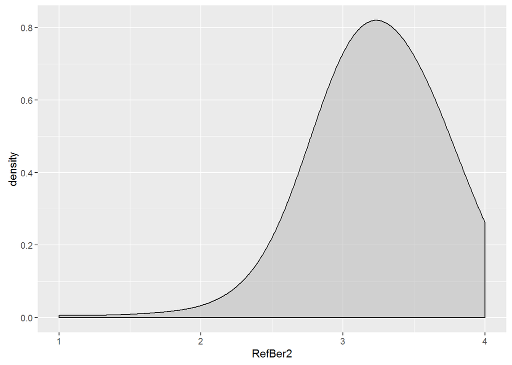

## expectancy value

- source: adaption of Eccles expectancy value model
- question type: likert scale
- number of items: 5
- names and label of items:
  - T2_ind_wert_intr = “Inwiefern stimmen Sie folgenden Aussagen zu? **Ich hätte gern mehr Seminare zum Thema Classroom-Management.**”
  - T2_ind_wert_util1 = “Inwiefern stimmen Sie folgenden Aussagen zu? **Gute Fähigkeiten im Classroom-Management werde ich für mein späteres Leben benötigen.**”
  - T2_ind_wert_cost1 = “Inwiefern stimmen Sie folgenden Aussagen zu? **Im Seminar muss ich viel Zeit aufwenden, um eine gute Note zu erzielen.**”
  - T2_ind_wert_cost2 = “Inwiefern stimmen Sie folgenden Aussagen zu? **Um im Seminar gut zu sein, müsste ich viel Freizeit opfern.**”
  - T2_ind_wert_util2 = “Inwiefern stimmen Sie folgenden Aussagen zu? **Eine gute Note im Seminar kann mir später sehr nutzen.**”
- value lables and numbers:
  - 1 = “stimmt gar nicht”
  - 2 = “stimmt eher nicht”
  - 3 = “stimmt eher”
  - 4 = “stimmt genau”
- inverted items: -
- subscales:
  - cost: T2_ind_wert_cost1, T2_ind_wert_cost2
  - utility: T2_ind_wert_util1, T2_ind_wert_util2
- item statistics

| item | n | mean | sd | min | max |
| --- | --- | --- | --- | --- | --- |
| T2_ind_wert_intr | 552 | 2.86 | 0.78 | 1 | 4 |
| T2_ind_wert_util1 | 549 | 3.47 | 0.67 | 1 | 4 |
| T2_ind_wert_cost1 | 545 | 2.68 | 0.75 | 1 | 4 |
| T2_ind_wert_cost2 | 548 | 2.49 | 0.81 | 1 | 4 |
| T2_ind_wert_util2 | 551 | 2.6 | 0.85 | 1 | 4 |

- subscale statistics

| subscale | n | mean | sd | min | max | McDonaldsOmega |
| --- | --- | --- | --- | --- | --- | --- |
| cost | 550 | 2.59 | 0.71 | 1 | 4 | 0.81 |
| utility | 551 | 3.03 | 0.59 | 1 | 4 | 0.36 |

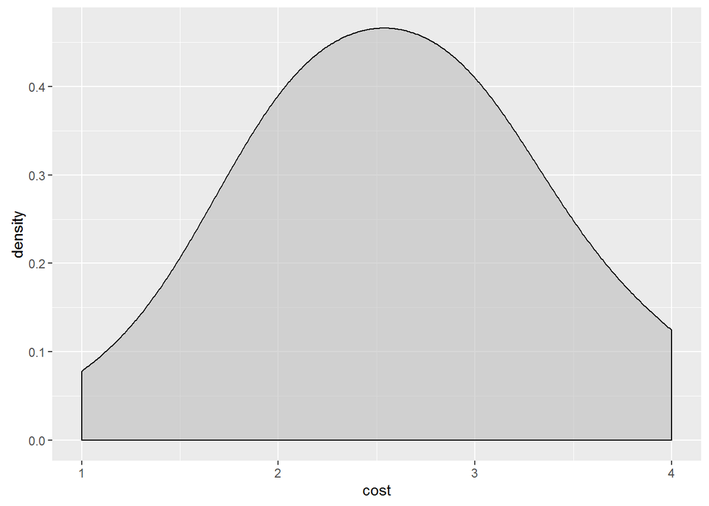

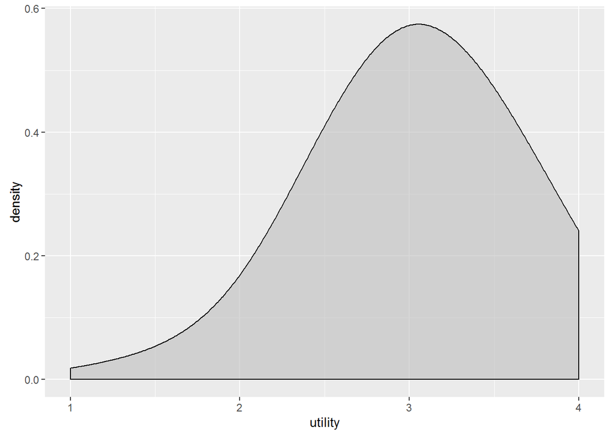

## willingness for effort

- source: adaption of SELLMO & TRAIN
- question type: likert scale
- number of items: 7
- names and label of items:
  - T2_anstrS_1 = “Worum geht es Ihnen im Seminar? Im Seminar geht es mir darum… **zu Hause keine Arbeit erledigen zu müssen.**”
  - T2_anstrS_2 = “Worum geht es Ihnen im Seminar? Im Seminar geht es mir darum… **aufwändige Aufgaben nicht selbst erledigen zu müssen.**”
  - T2_anstrS_3 = “Worum geht es Ihnen im Seminar? Im Seminar geht es mir darum… **mit wenig Arbeit durch die Veranstaltung zu kommen.**”
  - T2_anstrT_1 = “Wie sehr strengen Sie sich im Seminar an? **Ich bin im Seminar wirklich fleißig.**”
  - T2_anstrT_2 = “Wie sehr strengen Sie sich im Seminar an? **Ich tue im Seminar mein Bestes.**”
  - T2_anstrT_3 = “Wie sehr strengen Sie sich im Seminar an? **Ich strenge mich im Seminar wirklich an.**”
  - T2_anstrT_4 = “Wie sehr strengen Sie sich im Seminar an? **Im Seminar bearbeite ich alle Aufgaben und Hausaufgaben sehr ordentlich.**”
- value lables and numbers:
  - 1 = “stimmt gar nicht”
  - 2 = “stimmt eher nicht”
  - 3 = “stimmt eher”
  - 4 = “stimmt genau”
- inverted items: -
- subscales:
  - sellmo: T2_anstrS_1, T2_anstrS_2, T2_anstrS_3
  - train: T2_anstrT_1, T2_anstrT_2, T2_anstrT_3, T2_anstrT_4
- item statistics

| item | n | mean | sd | min | max |
| --- | --- | --- | --- | --- | --- |
| T2_anstrS_1 | 549 | 2.1 | 0.73 | 1 | 4 |
| T2_anstrS_2 | 548 | 2.06 | 0.76 | 1 | 4 |
| T2_anstrS_3 | 548 | 2.16 | 0.83 | 1 | 4 |
| T2_anstrT_1 | 550 | 2.59 | 0.68 | 1 | 4 |
| T2_anstrT_2 | 549 | 2.7 | 0.73 | 1 | 4 |
| T2_anstrT_3 | 544 | 2.68 | 0.71 | 1 | 4 |
| T2_anstrT_4 | 550 | 2.72 | 0.76 | 1 | 4 |

- subscale statistics

| subscale | n | mean | sd | min | max | McDonaldsOmega |
| --- | --- | --- | --- | --- | --- | --- |
| SELLMO | 549 | 2.11 | 0.65 | 1 | 4 | 0.9 |
| TRAIN | 550 | 2.7 | 0.64 | 1 | 4 | 0.9 |

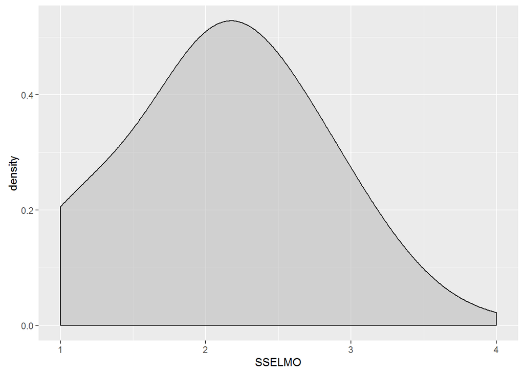

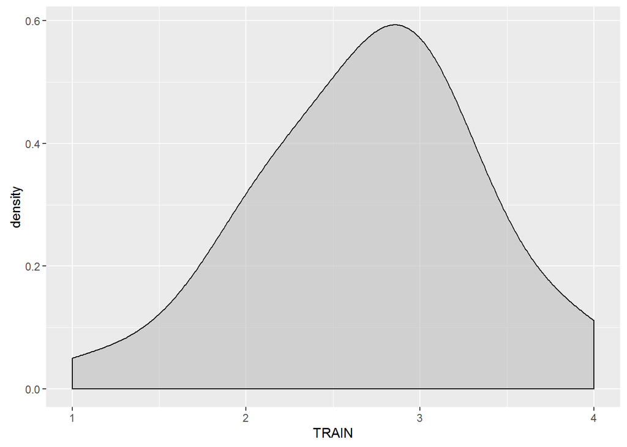

## constructivist learning beliefs

- source: adaption of Staub, F., & Stern, E. (2002). The nature of teacher’s pedagogical content beliefs matters for students’ achievement gains: quasi-experimental evidence from elementary mathematics. *Journal of Educational Psychology, 94* (2), 344-355.
- question type: likert scale
- number of items: 6
- names and label of items:
  - T2_knstr_1 = “Inwiefern stimmen Sie folgenden Aussagen zu? **Studierende lernen am besten, indem sie selbst Wege zur Lösung von Problemen entdecken.**”
  - T2_knstr_2 = “Inwiefern stimmen Sie folgenden Aussagen zu? **Man sollte Studierenden erlauben, sich eigene Wege zur Lösung von Anwendungsproblemen auszudenken, bevor die Lehrperson vorführt, wie diese zu lösen sind.**”
  - T2_knstr_3 = “Inwiefern stimmen Sie folgenden Aussagen zu? **Studierende können bei vielen Problemstellung auch ohne die Hilfe der Lehrenden Lösungswege finden.**”
  - T2_knstr_4 = “Inwiefern stimmen Sie folgenden Aussagen zu? **Pädagogik sollte so gelehrt werden, dass die Studierenden Zusammenhänge selbst entdecken können.**”
  - T2_knstr_5 = “Inwiefern stimmen Sie folgenden Aussagen zu? **Es hilft Studierenden, Pädagogik zu begreifen, wenn man sie ihre eigenen Lösungsideen diskutieren lässt.**”
  - T2_knstr_6 = “Inwiefern stimmen Sie folgenden Aussagen zu? **Studierende sollte häufig Gelegenheit gegeben werden, in Paaren/Kleingruppen Anwendungsprobleme gemeinsam zu lösen**”
- value lables and numbers:
  - 1 = “stimmt gar nicht”
  - 2 = “stimmt nur teilweise”
  - 3 = “stimmt größtenteils”
  - 4 = “stimmt genau”
- inverted items: -
- subscales: -
- item statistics

| item | n | mean | sd | min | max |
| --- | --- | --- | --- | --- | --- |
| T2_knstr_1 | 552 | 3.05 | 0.69 | 1 | 4 |
| T2_knstr_2 | 550 | 3.05 | 0.71 | 1 | 4 |
| T2_knstr_3 | 549 | 2.85 | 0.7 | 1 | 4 |
| T2_knstr_4 | 550 | 3.09 | 0.7 | 1 | 4 |
| T2_knstr_5 | 552 | 3.24 | 0.68 | 1 | 4 |
| T2_knstr_6 | 551 | 3.01 | 0.8 | 1 | 4 |

- scale statistics

| n | mean | sd | min | max | McDonaldsOmega |
| --- | --- | --- | --- | --- | --- |
| 552 | 3.05 | 0.5 | 1 | 4 | 0.85 |

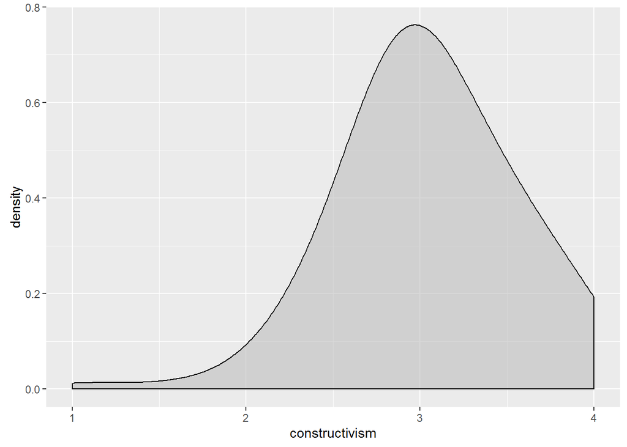

## interest in classroom management

- source: adaption of Anna-Lena Diecke
- question type: likert scale
- number of items: 6
- names and label of items:
  - T2_int_1 = “Wie interessant finden Sie Inhalte zum Thema Classroom Management? **Für das Thema Classroom Management interessiere ich mich.**”
  - T2_int_2 = “Wie interessant finden Sie Inhalte zum Thema Classroom Management? **Ich beschäftige mich gerne mit Büchern oder Aufgaben, die etwas mit dem Thema Classroom Management zu tun haben.**”
  - T2_int_3 = “Wie interessant finden Sie Inhalte zum Thema Classroom Management? **Die Beschäftigung mit dem Thema Classroom Management gehört zu meinen Lieblingstätigkeiten.**”
  - T2_int_4 = “Wie interessant finden Sie Inhalte zum Thema Classroom Management? **Oft finde ich das, was wir an der Universität zum Thema Classroom Management durchnehmen, richtig spannend.**”
  - T2_int_5 = “Wie interessant finden Sie Inhalte zum Thema Classroom Management? **Oft bin ich nach dem Seminar schon neugierig auf die nächste Sitzung.**”
  - T2_int_6 = “Wie interessant finden Sie Inhalte zum Thema Classroom Management? **Mit bestimmten Fragen zum Thema Classroom Management würde ich mich gern noch viel mehr beschäftigen.**”
- value lables and numbers:
  - 1 = “stimmt gar nicht”
  - 2 = “stimmt eher nicht”
  - 3 = “stimmt eher”
  - 4 = “stimmt genau”
- inverted items: -
- subscales: -
- item statistics

| item | n | mean | sd | min | max |
| --- | --- | --- | --- | --- | --- |
| T2_int_1 | 549 | 3.12 | 0.67 | 1 | 4 |
| T2_int_2 | 547 | 2.18 | 0.74 | 1 | 4 |
| T2_int_3 | 551 | 1.83 | 0.7 | 1 | 4 |
| T2_int_4 | 551 | 2.7 | 0.74 | 1 | 4 |
| T2_int_5 | 549 | 2.33 | 0.77 | 1 | 4 |
| T2_int_6 | 551 | 2.68 | 0.78 | 1 | 4 |

- scale statistics

| n | mean | sd | min | max | McDonaldsOmega |
| --- | --- | --- | --- | --- | --- |
| 552 | 2.47 | 0.55 | 1 | 4 | 0.89 |

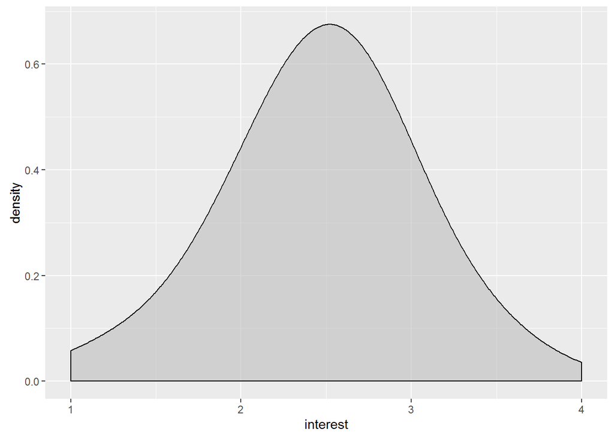

## practical relevance of the course

- source: adaption of COAKTIV, Pisa 2003
- question type: likert scale
- number of items: 5
- names and label of items:
  - T2_prak_1 = “Wie finden Sie die Inhalte im Seminar? **Im Seminar kann man kaum etwas lernen, was in der Wirklichkeit von Nutzen ist.**”
  - T2_prak_2 = “Wie finden Sie die Inhalte im Seminar? **Nur wenige Dinge, die wir im Seminar lernen, kann man später verwenden.**”
  - T2_prak_3 = “Wie finden Sie die Inhalte im Seminar? **Was wir im Seminar lernen, ist nützlich in vielen anderen Bereichen.**”
  - T2_prak_4 = “Wie finden Sie die Inhalte im Seminar? **Im Seminar beschäftigen wir uns mit Aufgaben, die einen praktischen Nutzen haben.**”
  - T2_prak_5 = “Wie finden Sie die Inhalte im Seminar? **Was wir im Seminar lernen, hilft, alltägliche Aufgaben und Probleme zu lösen.**”
- value lables and numbers:
  - 1 = “stimmt gar nicht”
  - 2 = “stimmt eher nicht”
  - 3 = “stimmt eher”
  - 4 = “stimmt genau”
- inverted items: T2_prak_1, T2_prak_2
- subscales: -
- item statistics

| item | n | mean | sd | min | max |
| --- | --- | --- | --- | --- | --- |
| T2_prak_1 recoded | 550 | 2.92 | 0.82 | 1 | 4 |
| T2_prak_2 recoded | 545 | 2.89 | 0.82 | 1 | 4 |
| T2_prak_3 | 550 | 2.65 | 0.74 | 1 | 4 |
| T2_prak_4 | 549 | 2.87 | 0.72 | 1 | 4 |
| T2_prak_5 | 551 | 2.39 | 0.81 | 1 | 4 |

- scale statistics

| n | mean | sd | min | max | McDonaldsOmega |
| --- | --- | --- | --- | --- | --- |
| 551 | 2.74 | 0.6 | 1 | 4 | 0.86 |

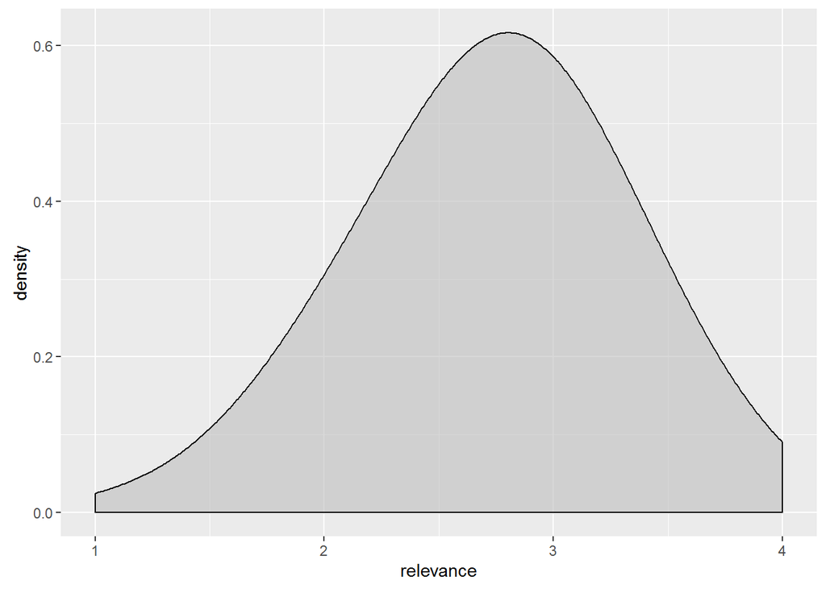

## attitude toward cooperative learning

- source: adaption of PISA 2000
- question type: likert scale
- number of items: 5
- names and label of items:
  - T2_koop_1 = “Inwiefern stimmen Sie den folgenden Aussagen zu? **Ich finde es nützlich, die Ideen von allen zusammen zu bringen, wenn man an einem Projekt arbeitet.**”
  - T2_koop_2 = “Inwiefern stimmen Sie den folgenden Aussagen zu? **Ich helfe anderen gern dabei, in einer Gruppe gute Arbeit zu leisten.**”
  - T2_koop_3 = “Inwiefern stimmen Sie den folgenden Aussagen zu? **Die beste Arbeit leiste ich, wenn ich mit anderen Studierenden zusammen arbeite.**”
  - T2_koop_4 = “Inwiefern stimmen Sie den folgenden Aussagen zu? **Am meisten lerne ich, wenn ich mit anderen Studierenden zusammen arbeite.**”
  - T2_koop_5 = “Inwiefern stimmen Sie den folgenden Aussagen zu? **Ich arbeite gern mit anderen Studierenden zusammen.**”
- value lables and numbers:
  - 1 = “trifft überhaupt nicht zu”
  - 2 = “”
  - 3 = “”
  - 4 = “”
  - 5 = “”
  - 6 = “”
  - 7 = “trifft voll und ganz zu”
- inverted items: -
- subscales: -
- item statistics

| item | n | mean | sd | min | max |
| --- | --- | --- | --- | --- | --- |
| T2_koop_1 | 550 | 5.41 | 1.3 | 1 | 7 |
| T2_koop_2 | 550 | 5.47 | 1.25 | 1 | 7 |
| T2_koop_3 | 551 | 4.41 | 1.53 | 1 | 7 |
| T2_koop_4 | 550 | 4.46 | 1.57 | 1 | 7 |
| T2_koop_5 | 551 | 5.31 | 1.49 | 1 | 7 |

- scale statistics

| n | mean | sd | min | max | McDonaldsOmega |
| --- | --- | --- | --- | --- | --- |
| 551 | 5.01 | 1.18 | 1 | 7 | 0.93 |

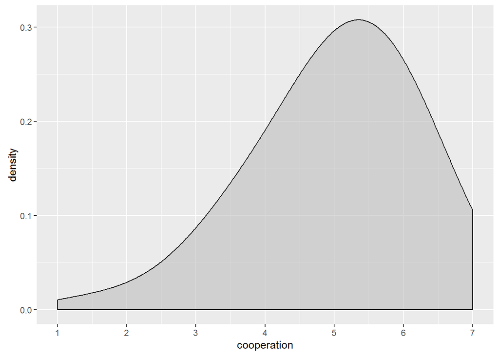

## self-perceived knowledge of classroom management

- source: own creation
- question type: likert scale
- number of items: 15
- names and label of items:
  - T2_wiss_crm_verh1 = “Bitte geben Sie Ihre Meinung an. **Ich kenne Strategien zum Umgang mit massiven Störungen.**”
  - T2_wiss_crm_verh2 = “Bitte geben Sie Ihre Meinung an. **Ich kenne verschiedene Möglichkeiten, auf Störungen zu reagieren, ohne den Unterrichtsfluss zu beeinträchtigen.**”
  - T2_wiss_crm_verh3 = “Bitte geben Sie Ihre Meinung an. **Ich kenne verschiedene Strategien, mit Regelverstößen umzugehen.**”
  - T2_wiss_crm_verh4 = “Bitte geben Sie Ihre Meinung an. **Ich weiß, wie ich auf Regelverstöße reagieren kann.**”
  - T2_wiss_crm_verh5 = “Bitte geben Sie Ihre Meinung an. **Ich kenne Möglichkeiten, präventiv Störungen zu vermeiden.**”
  - T2_wiss_crm_verh6 = “Bitte geben Sie Ihre Meinung an. **Ich kenne Prozeduren und Rituale, die zu einem reibungslosen Unterrichtsverlauf beitragen.**”
  - T2_wiss_crm_bez1 = “Bitte geben Sie Ihre Meinung an. **Ich kenne Möglichkeiten, mit Schülern ein Arbeitsbündnis herzustellen**”
  - T2_wiss_crm_bez2 = “Bitte geben Sie Ihre Meinung an. **Ich kenne Strategien, um Schüler zum Lernen zu motivieren.**”
  - T2_wiss_crm_unt1 = “Bitte geben Sie Ihre Meinung an. **Ich kenne verschiedene Strategien, um möglichst viele Schüler aktiv in den Unterricht einzubeziehen.**”
  - T2_wiss_crm_unt2 = “Bitte geben Sie Ihre Meinung an. **Ich weiß, wie ich unbeteiligte Schüler einbinden kann.**”
  - T2_wiss_crm_unt3 = “Bitte geben Sie Ihre Meinung an. **Ich kenne verschiedene Strategien, um den Schülern den roten Faden der Stunde zu verdeutlichen.**”
  - T2_wiss_crm_test = “Bitte geben Sie Ihre Meinung an. **Bitte kreuzen Sie in dieser Zeile „trifft vollkommen zu“ an.**”
  - T2_wiss_crm_unt4 = “Bitte geben Sie Ihre Meinung an. **Ich weiß, wie ich Aufgaben erklären muss, damit die Schüler sie verstehen.**”
  - T2_wiss_crm_unt5 = “Bitte geben Sie Ihre Meinung an. **Ich kenne Strategien, eine Stunde so zu planen, dass die Unterrichtszeit optimal genutzt werden kann.**”
  - T2_wiss_crm_unt6 = “Bitte geben Sie Ihre Meinung an. **Ich kenne Strategien, um Wartezeiten, Verzögerungen oder schleppende Übergänge zu vermeiden.**”
- value lables and numbers:
  - 1 = “trifft gar nicht zu”
  - 2 = “”
  - 3 = “”
  - 4 = “”
  - 5 = “”
  - 6 = “trifft vollkommen zu”
- inverted items: -
- subscales:
  - Verhaltenskontrolle: T2_wiss_crm_verh1, T2_wiss_crm_verh2, T2_wiss_crm_verh3, T2_wiss_crm_verh4, T2_wiss_crm_verh5, T2_wiss_crm_verh6
  - Beziehungsgestaltung: T2_wiss_crm_bez1, T2_wiss_crm_bez2
  - Unterrichtsgestaltung: T2_wiss_crm_unt1, T2_wiss_crm_unt2, T2_wiss_crm_unt3, T2_wiss_crm_unt4, T2_wiss_crm_unt5, T2_wiss_crm_unt6
  - control item : T2_wiss_crm_test
- item statistics

| item | n | mean | sd | min | max |
| --- | --- | --- | --- | --- | --- |
| T2_wiss_crm_verh1 | 550 | 3.88 | 1.16 | 1 | 6 |
| T2_wiss_crm_verh2 | 551 | 3.95 | 1.13 | 1 | 6 |
| T2_wiss_crm_verh3 | 551 | 3.99 | 1.07 | 1 | 6 |
| T2_wiss_crm_verh4 | 547 | 4.03 | 1.09 | 1 | 6 |
| T2_wiss_crm_verh5 | 546 | 3.99 | 1.18 | 1 | 6 |
| T2_wiss_crm_verh6 | 545 | 4.02 | 1.09 | 1 | 6 |
| T2_wiss_crm_bez1 | 550 | 3.98 | 1.12 | 1 | 6 |
| T2_wiss_crm_bez2 | 551 | 4.17 | 1.06 | 1 | 6 |
| T2_wiss_crm_unt1 | 548 | 4.24 | 1.01 | 1 | 6 |
| T2_wiss_crm_unt2 | 549 | 4 | 1.11 | 1 | 6 |
| T2_wiss_crm_unt3 | 550 | 4 | 1.1 | 1 | 6 |
| T2_wiss_crm_test | 549 | 5.86 | 0.71 | 1 | 6 |
| T2_wiss_crm_unt4 | 545 | 4.27 | 1.04 | 1 | 6 |
| T2_wiss_crm_unt5 | 550 | 3.63 | 1.23 | 1 | 6 |
| T2_wiss_crm_unt6 | 547 | 3.78 | 1.15 | 1 | 6 |

- subscale statistics

| subscale | n | mean | sd | min | max | McDonaldsOmega |
| --- | --- | --- | --- | --- | --- | --- |
| verhaltenskontrolle | 551 | 3.98 | 0.95 | 1 | 6 | 0.95 |
| beziehungsgestaltung | 551 | 4.08 | 0.97 | 1 | 6 | 0.73 |
| unterrichtsgestaltung | 551 | 3.99 | 0.85 | 1 | 6 | 0.91 |

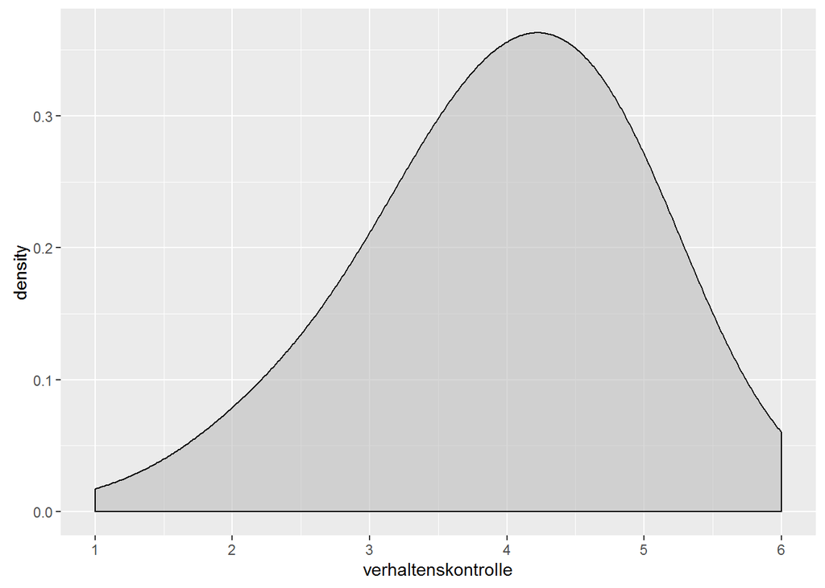

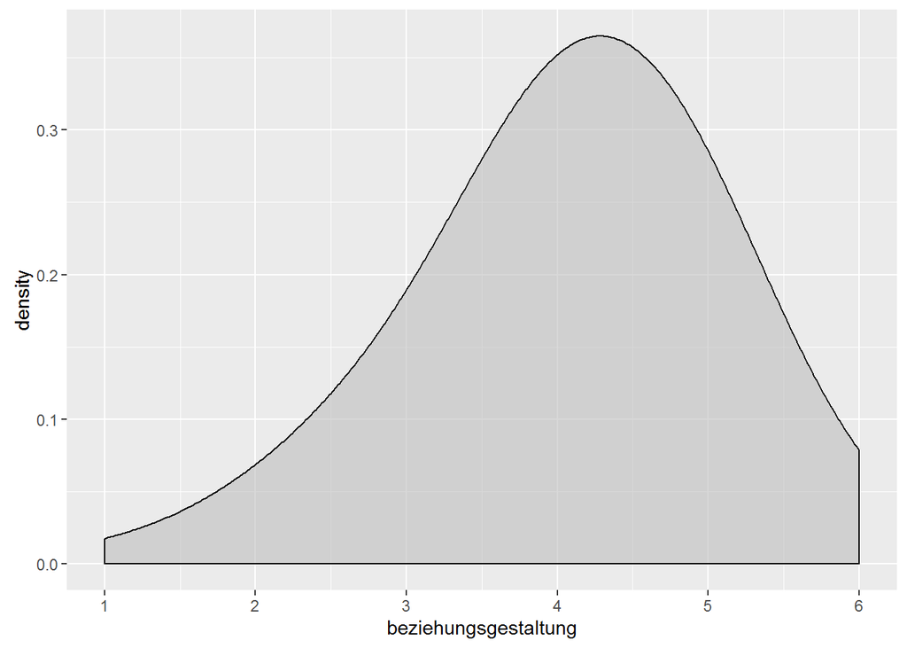

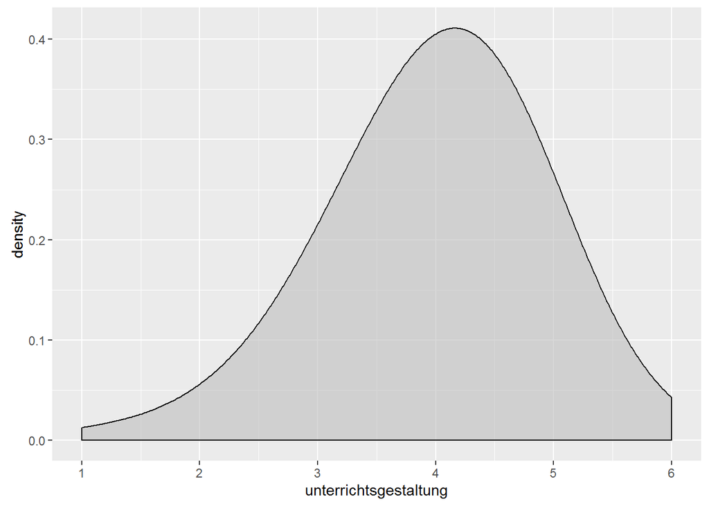

## knowledge of classroom management

- source: own creation
- question type: open question
- number of items: 2
- names and label of items:
  - T2_wiss_crm_preav = “Nennen Sie präventive Maßnahmen, die für einen störungsfreien Unterricht sorgen sollen.”
  - T2_wiss_crm_bez = “Nennen Sie Maßnahmen, die die Lehrer-Schüler-Beziehung verbessern und so zu einem besseren Lernklima führen (Beziehungsförderung).”

## goal orientation

- source: adaption of PISA 2000, Feldtest
- question type: likert scale
- number of items: 9
- names and label of items:
  - T2_ziel_9 = “Inwiefern stimmen Sie folgenden Aussagen zu? Ich fühle mich am erfolgreichsten, … **wenn ich zeigen kann, dass ich schlau bin.**”
  - T2_ziel_7 = “Inwiefern stimmen Sie folgenden Aussagen zu? Ich fühle mich am erfolgreichsten, … **wenn ich als einziger die richtige Antwort weiß.**”
  - T2_ziel_4 = “Inwiefern stimmen Sie folgenden Aussagen zu? Ich fühle mich am erfolgreichsten, … **wenn ich einen neuen Weg herausfinde, ein Problem zu lösen.**”
  - T2_ziel_2 = “Inwiefern stimmen Sie folgenden Aussagen zu? Ich fühle mich am erfolgreichsten, … **wenn das Gelernte mich dazu bringt mehr erfahren zu wollen.**”
  - T2_ziel_1 = “Inwiefern stimmen Sie folgenden Aussagen zu? Ich fühle mich am erfolgreichsten, … **wenn ich ein kompliziertes Problem endlich bewältigt habe.**”
  - T2_ziel_8 = “Inwiefern stimmen Sie folgenden Aussagen zu? Ich fühle mich am erfolgreichsten, … **wenn ich bessere Noten bekomme als die anderen.**”
  - T2_ziel_6 = “Inwiefern stimmen Sie folgenden Aussagen zu? Ich fühle mich am erfolgreichsten, … **wenn ich mehr weiß als die anderen.**”
  - T2_ziel_3 = “Inwiefern stimmen Sie folgenden Aussagen zu? Ich fühle mich am erfolgreichsten, … **wenn das Seminar mich zum Nachdenken bringt.**”
  - T2_ziel_5 = “Inwiefern stimmen Sie folgenden Aussagen zu? Ich fühle mich am erfolgreichsten, … **wenn das Gelernte wirklich Sinn für mich macht.**”
- value lables and numbers:
  - 1 = “trifft überhaupt nicht zu”
  - 2 = “”
  - 3 = “”
  - 4 = “”
  - 5 = “”
  - 6 = “”
  - 7 = “trifft voll und ganz zu”
- inverted items: -
- subscales:
  - Aufgabenorieniterung: T2_ziel_1, T2_ziel_2, T2_ziel_3, T2_ziel_4, T2_ziel_5
  - Ich-orientierung: T2_ziel_6, T2_ziel_7, T2_ziel_8, T2_ziel_9
- item statistics

| item | n | mean | sd | min | max |
| --- | --- | --- | --- | --- | --- |
| T2_ziel_1 | 546 | 5.88 | 1.18 | 1 | 7 |
| T2_ziel_2 | 546 | 5.32 | 1.27 | 1 | 7 |
| T2_ziel_3 | 543 | 4.59 | 1.54 | 1 | 7 |
| T2_ziel_4 | 546 | 5.49 | 1.26 | 1 | 7 |
| T2_ziel_5 | 547 | 5.86 | 1.31 | 1 | 7 |
| T2_ziel_6 | 544 | 4.33 | 1.79 | 1 | 7 |
| T2_ziel_7 | 546 | 4.15 | 1.73 | 1 | 7 |
| T2_ziel_8 | 546 | 4.12 | 1.77 | 1 | 7 |
| T2_ziel_9 | 546 | 4.35 | 1.65 | 1 | 7 |

- subscale statistics

| subscale | n | mean | sd | min | max | McDonaldsOmega |
| --- | --- | --- | --- | --- | --- | --- |
| aufgebenorientierung | 548 | 5.43 | 1.01 | 1 | 7 | 0.89 |
| ichroientierung | 547 | 4.24 | 1.54 | 1 | 7 | 0.95 |

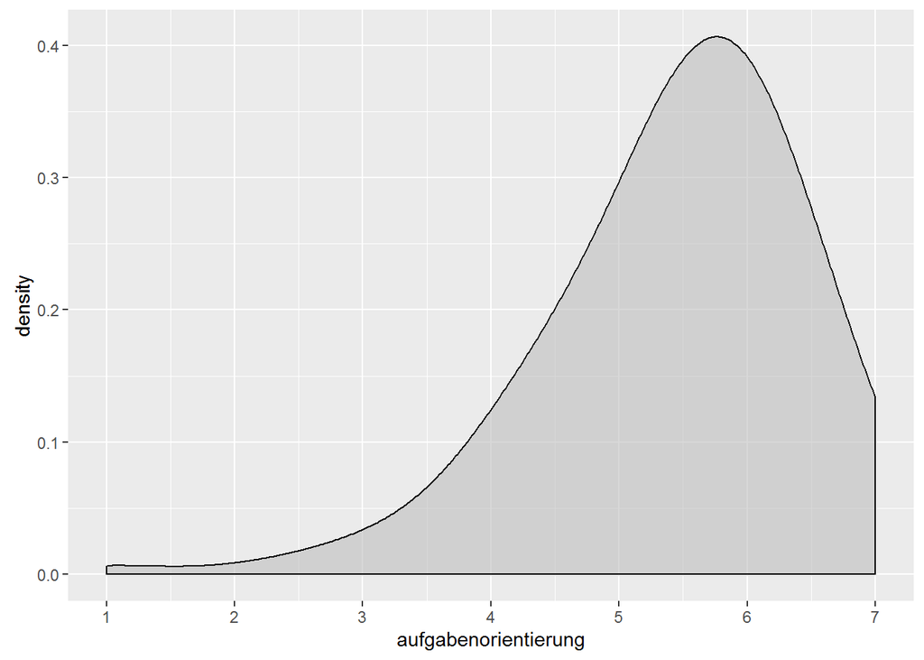

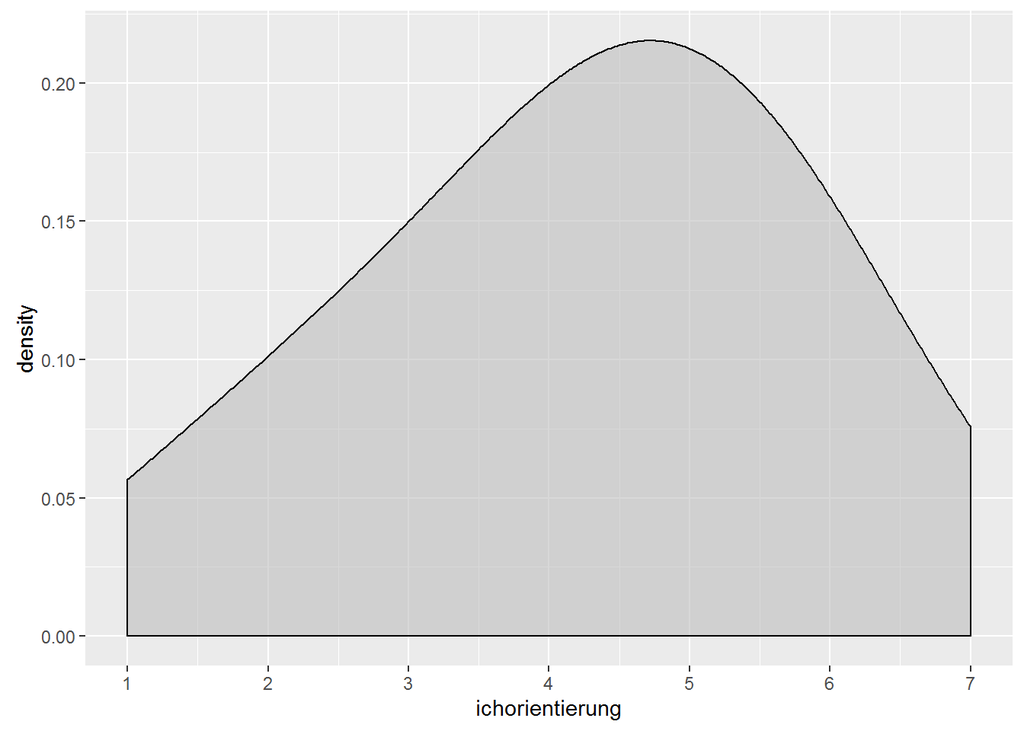

## big 5 personality test

- source: Rammstedt/John 2007, S. 203-212
- question type: likert scale
- number of items: 10
- names and label of items:
  - big5_1 = “Inwieweit treffen die folgenden Aussagen auf dich zu? **Ich bin eher zurückhaltend, reserviert.** ”
  - big5_2 = “Inwieweit treffen die folgenden Aussagen auf dich zu? **Ich schenke anderen leicht Vertrauen, glaube an das Gute im Menschen.** ”
  - big5_3 = “Inwieweit treffen die folgenden Aussagen auf dich zu? **Ich bin bequem, neige zu Faulheit.** ”
  - big5_4 = “Inwieweit treffen die folgenden Aussagen auf dich zu? **Ich bin entspannt, lasse mich durch Stress nicht aus der Ruhe bringen.** ”
  - big5_5 = “Inwieweit treffen die folgenden Aussagen auf dich zu? **Ich habe nur wenig künstlerisches Interesse.** ”
  - big5_6 = “Inwieweit treffen die folgenden Aussagen auf dich zu? **Ich gehe aus mir heraus, bin gesellig.** ”
  - big5_7 = “Inwieweit treffen die folgenden Aussagen auf dich zu? **Ich neige dazu, andere zu kritisieren.** ”
  - big5_8 = “Inwieweit treffen die folgenden Aussagen auf dich zu? **Ich erledige Aufgaben gründlich.** ”
  - big5_9 = “Inwieweit treffen die folgenden Aussagen auf dich zu? **Ich werde leicht nervös und unsicher.**”
  - big5_10 = “Inwieweit treffen die folgenden Aussagen auf dich zu? **Ich habe eine aktive Vorstellungskraft, bin phantasievoll.**”
- value lables and numbers:
  - 1 = “trifft überhaupt nicht zu”
  - 2 = “trifft eher nicht zu”
  - 3 = “trifft teilwise zu”
  - 4 = “trifft eher zu”
  - 5 = “trifft voll und ganz zu”
- inverted items: big5_3, big5_5, big5_6, big5_7, big5_9
- subscales:
  - intra/extraversion: big5_1, big5_6
  - compatibleness: big5_2, big5_7
  - rigidity: big5_3, big5_8
  - neuroticism: big5_4, big5_9
  - openness: big5_5, big5_10
- item statistics

[output not shown]

- subscale statistics

| subscale | n | mean | sd | min | max | McDonaldsOmega |
| --- | --- | --- | --- | --- | --- | --- |
| intra/extraversion | 549 | 2.43 | 0.85 | 1 | 5 | 0.69 |
| compatibleness | 549 | 3.32 | 0.74 | 1 | 5 | 0.17 |
| rigidity | 549 | 3.59 | 0.83 | 1 | 5 | 0.58 |
| neuroticism | 549 | 2.59 | 0.72 | 1 | 5 | 0.13 |
| openness | 549 | 3.73 | 0.96 | 1 | 5 | 0.56 |

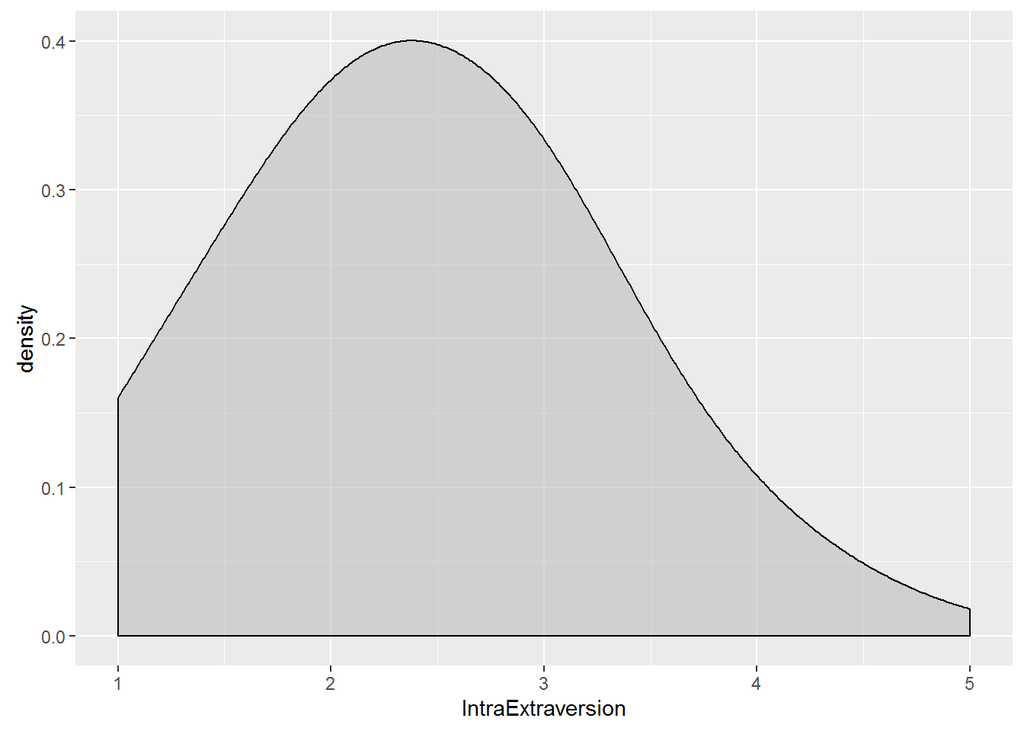

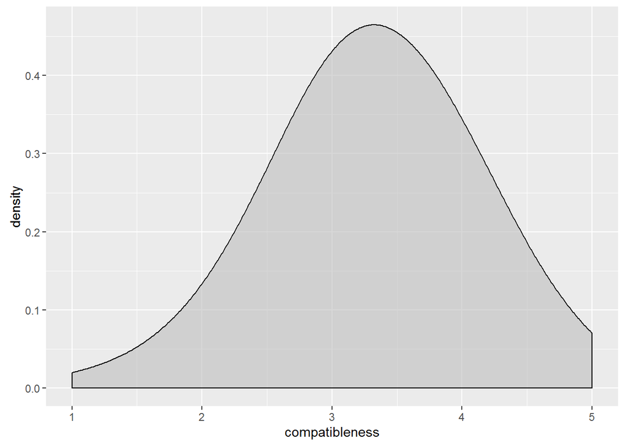

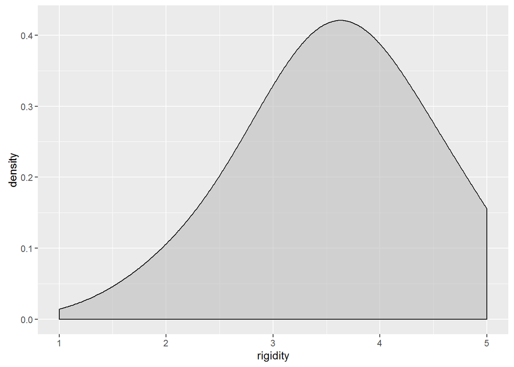

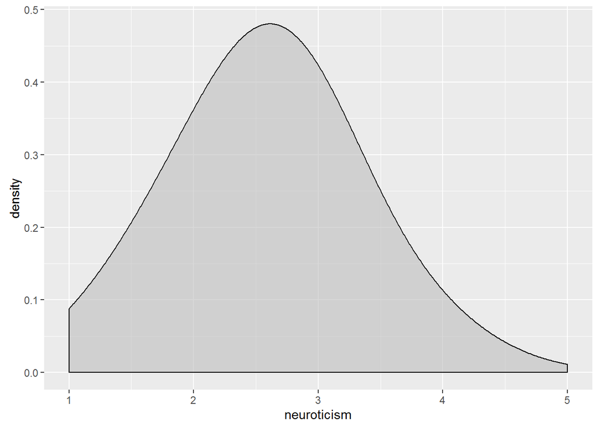

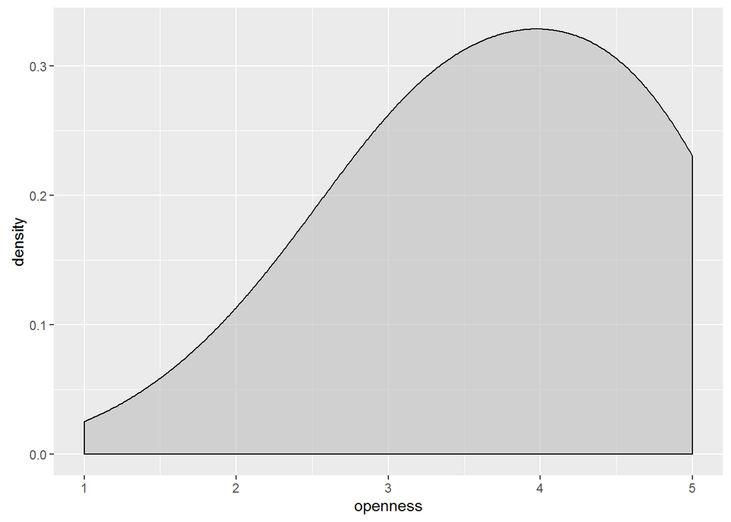